# Homework 2

李娜 Lina~

2019/3/28

# Introduction

In this homework, I will use the dataset *student-mat.csv* to do some analysis based on the lecture 1-**Regression**. This data is downloadwd from **Kaggle**-[Student Grade Prediction](https://www.kaggle.com/dipam7/student-grade-prediction).

This data attributes include student math grades(three periods), demographic(sex,age,etc), family(parent’s eudcation,job and relationship),social (eg:go out with friends) and school-related features(absences).there are 30 input variables and 3 output variables.

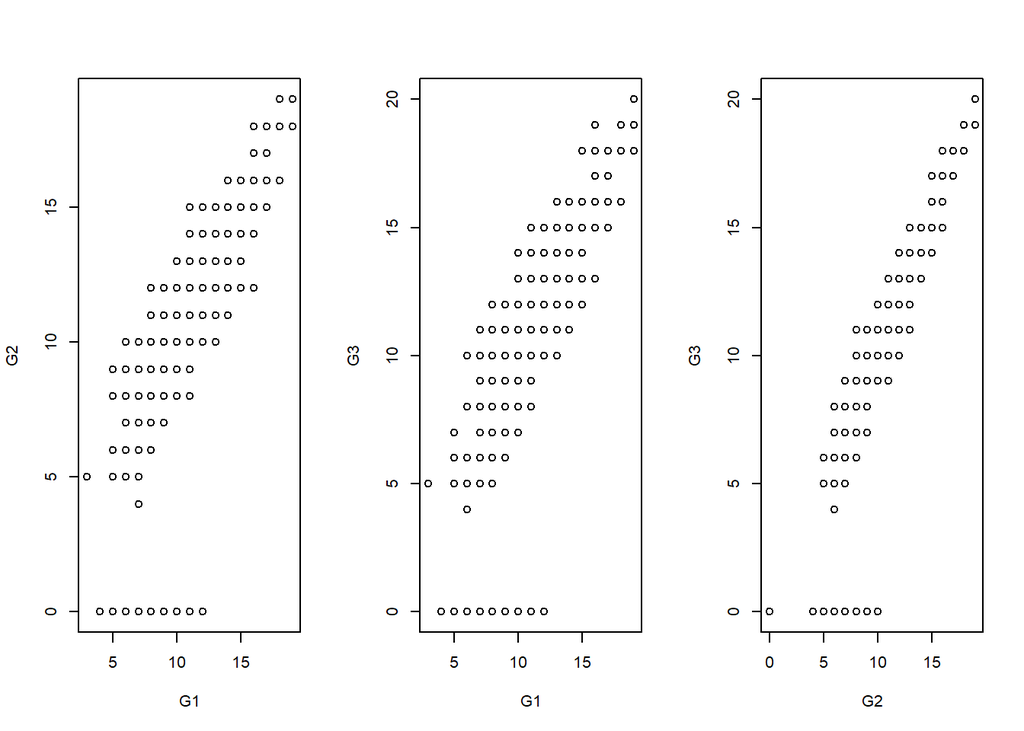

```r
grade<-read.csv("student-mat.csv")
attach(grade)
par(mfrow=c(1,3))
plot(G1,G2)
plot(G1,G3)
plot(G2,G3)
```

From above plots,we can find the three periods’ math grades are highly positive correlated. So we only care about the third period,that is, final grade.

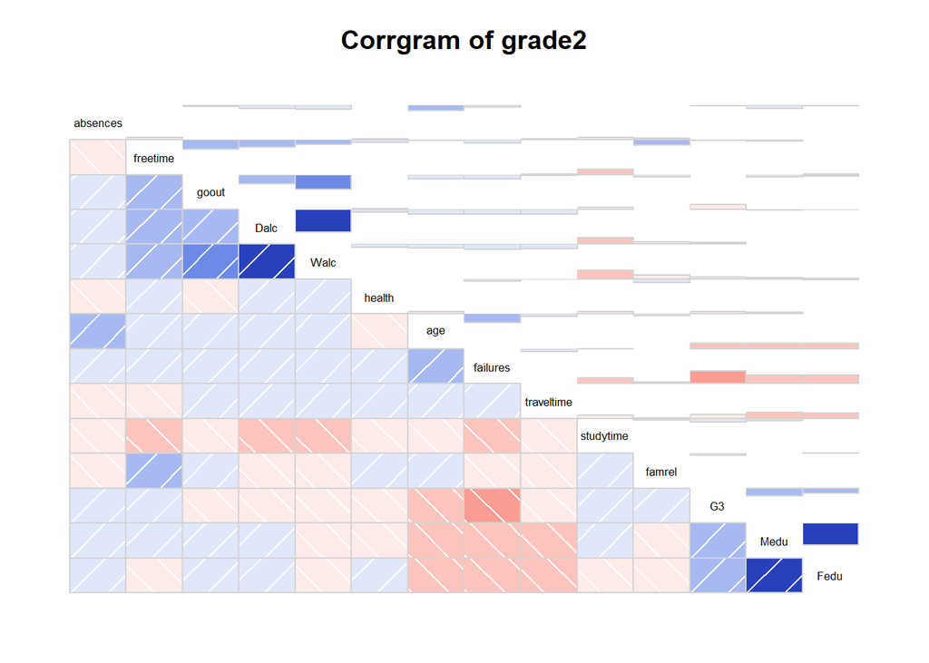

```r
grade2<-grade[,c(1:30,33)]
library(AER)
require(corrgram)
corrgram(grade2,order=TRUE,lower.panel = panel.shade,upper.panel = panel.bar,
         text.panel = panel.txt,main="Corrgram of grade2")
```

```r
reg<-lm(G3~.,data = grade2)
coeftest(reg)
```

```
##
## t test of coefficients:
##
##                   Estimate Std. Error t value  Pr(>|t|)
## (Intercept)      14.077693   4.480888  3.1417  0.001821 **
## schoolMS          0.725551   0.791568  0.9166  0.359974
## sexM              1.262362   0.500029  2.5246  0.012019 *
## age              -0.375159   0.217214 -1.7271  0.085012 .
## addressU          0.551350   0.584119  0.9439  0.345863
## famsizeLE3        0.702806   0.488241  1.4395  0.150900
## PstatusT         -0.320096   0.723897 -0.4422  0.658625
## Medu              0.456866   0.323169  1.4137  0.158325
## Fedu             -0.104576   0.277619 -0.3767  0.706631
## Mjobhealth        0.998083   1.118186  0.8926  0.372681
## Mjobother        -0.359002   0.713163 -0.5034  0.614999
## Mjobservices      0.658322   0.797839  0.8251  0.409851
## Mjobteacher      -1.241490   1.038209 -1.1958  0.232573
## Fjobhealth        0.347674   1.437961  0.2418  0.809088
## Fjobother        -0.619668   1.023041 -0.6057  0.545093
## Fjobservices     -0.465772   1.056973 -0.4407  0.659723
## Fjobteacher       1.326187   1.296539  1.0229  0.307067
## reasonhome        0.078510   0.553803  0.1418  0.887345
## reasonother       0.777070   0.817571  0.9505  0.342524
## reasonreputation  0.613040   0.576566  1.0633  0.288386
## guardianmother    0.069780   0.545597  0.1279  0.898304
## guardianother     0.750104   0.999463  0.7505  0.453446
## traveltime       -0.240271   0.338965 -0.7088  0.478892
## studytime         0.549517   0.287655  1.9103  0.056895 .
## failures         -1.723977   0.332906 -5.1786 3.754e-07 ***
## schoolsupyes     -1.350584   0.666929 -2.0251  0.043607 *
## famsupyes        -0.861819   0.478690 -1.8004  0.072651 .
## paidyes           0.339748   0.477748  0.7111  0.477462
## activitiesyes    -0.329530   0.444942 -0.7406  0.459418
## nurseryyes       -0.177303   0.549311 -0.3228  0.747056
## higheryes         1.370451   1.077797  1.2715  0.204373
## internetyes       0.498135   0.619555  0.8040  0.421923
## romanticyes      -1.094494   0.469249 -2.3324  0.020236 *
## famrel            0.231551   0.245926  0.9415  0.347064
## freetime          0.302419   0.237353  1.2741  0.203450
## goout            -0.593671   0.224507 -2.6443  0.008548 **
## Dalc             -0.272229   0.330875 -0.8228  0.411200
## Walc              0.263385   0.248010  1.0620  0.288960
## health           -0.176781   0.161012 -1.0979  0.272974
## absences          0.056291   0.028966  1.9433  0.052766 .
## ---
## Signif. codes:  0 '***' 0.001 '**' 0.01 '*' 0.05 '.' 0.1 ' ' 1
```

First, I use dataset **grade2** to get a correlation coefficient diagram. For the correlation between G3 and other variables,we can see there exists positive correlation(studytime, famrel) as well as negative correlation(age, failures). Then I use all the input variables to run the OLS regression. The result shows that only several variables’coefficients are significant. It’s a little surpring that almost all the variables related to family are not significant.

Next, to simplify the analysis,I only pick up those significant variables.

```r
grade3<-data.frame(age,sex,studytime,failures,schoolsup,famsup,romantic,goout,absences,G3)
summary(grade3)
```

```
##       age       sex       studytime        failures      schoolsup
##  Min.   :15.0   F:208   Min.   :1.000   Min.   :0.0000   no :344
##  1st Qu.:16.0   M:187   1st Qu.:1.000   1st Qu.:0.0000   yes: 51
##  Median :17.0           Median :2.000   Median :0.0000
##  Mean   :16.7           Mean   :2.035   Mean   :0.3342
##  3rd Qu.:18.0           3rd Qu.:2.000   3rd Qu.:0.0000
##  Max.   :22.0           Max.   :4.000   Max.   :3.0000
##  famsup    romantic      goout          absences            G3
##  no :153   no :263   Min.   :1.000   Min.   : 0.000   Min.   : 0.00
##  yes:242   yes:132   1st Qu.:2.000   1st Qu.: 0.000   1st Qu.: 8.00
##                      Median :3.000   Median : 4.000   Median :11.00
##                      Mean   :3.109   Mean   : 5.709   Mean   :10.42
##                      3rd Qu.:4.000   3rd Qu.: 8.000   3rd Qu.:14.00
##                      Max.   :5.000   Max.   :75.000   Max.   :20.00
```

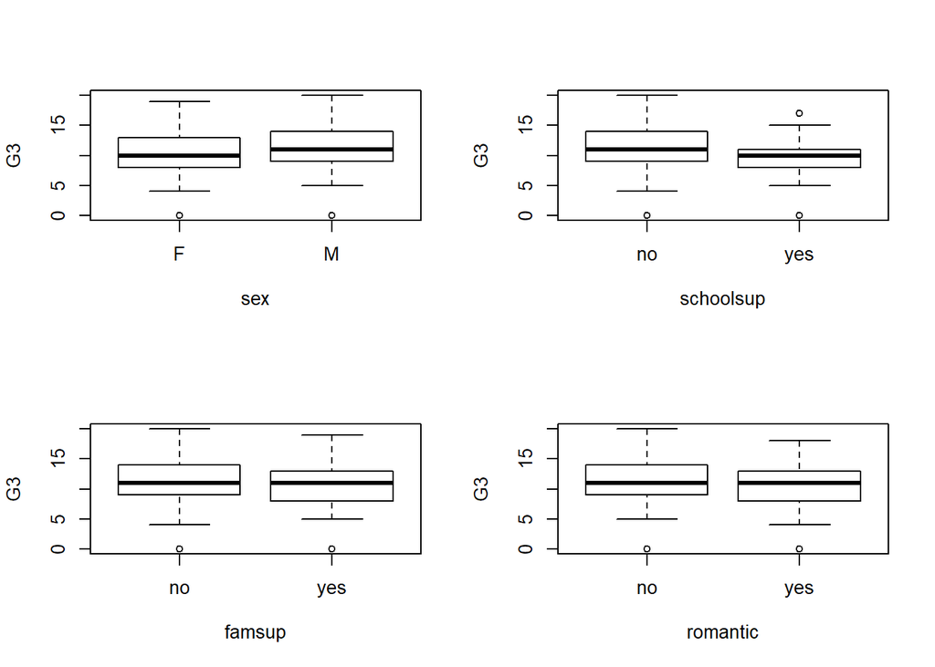

```r
par(mfrow=c(2,2))
boxplot(G3~sex,xlab="sex",ylab="G3")
boxplot(G3~schoolsup,xlab="schoolsup",ylab="G3")
boxplot(G3~famsup,xlab="famsup",ylab="G3")
boxplot(G3~romantic,xlab="romantic",ylab="G3")
```

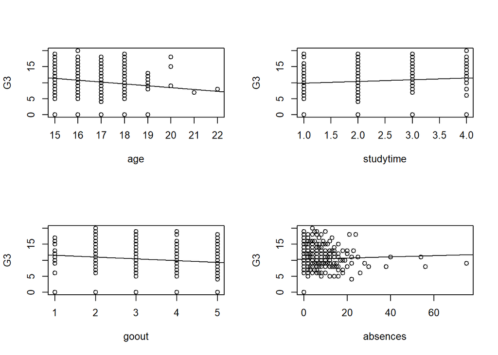

```r
plot(age,G3)
abline(lm(G3~age))
plot(studytime,G3)
abline(lm(G3~studytime))
plot(goout,G3)
abline(lm(G3~goout))
plot(absences,G3)
abline(lm(G3~absences))
```

```r
par(mfrow=c(1,1))
```

The simple plots show that male’s mean math grade is higher than female(*Well,it seems like we always thought of!*). No school support will give higher mean grade. The scatter plots also give us some impressions.For example, the more studytime,the higher grade.

## (1) Homoskedastic std error, robust std error and bootstrap

```r
coeftest(lm(G3~.,data = grade3))
```

```
##
## t test of coefficients:
##
##               Estimate Std. Error t value  Pr(>|t|)
## (Intercept)  17.493087   3.116606  5.6129 3.813e-08 ***
## age          -0.385419   0.182270 -2.1145   0.03511 *
## sexM          1.154702   0.452301  2.5530   0.01107 *
## studytime     0.549596   0.269380  2.0402   0.04201 *
## failures     -1.921798   0.298323 -6.4420 3.523e-10 ***
## schoolsupyes -1.421761   0.658499 -2.1591   0.03146 *
## famsupyes    -0.553655   0.443537 -1.2483   0.21269
## romanticyes  -0.967140   0.458549 -2.1091   0.03558 *
## goout        -0.380299   0.191613 -1.9847   0.04788 *
## absences      0.063460   0.027094  2.3423   0.01968 *
## ---
## Signif. codes:  0 '***' 0.001 '**' 0.01 '*' 0.05 '.' 0.1 ' ' 1
```

The result shows again boy’s math grade is higher than girl. Everything else being equal, boy’s score is 1.15 points higher than girl’s.

```r
coeftest(lm(G3~.,data = grade3),vcov=vcovHC)
```

```
##
## t test of coefficients:
##
##               Estimate Std. Error t value  Pr(>|t|)
## (Intercept)  17.493087   3.290461  5.3163 1.798e-07 ***
## age          -0.385419   0.197697 -1.9495   0.05196 .
## sexM          1.154702   0.458260  2.5198   0.01215 *
## studytime     0.549596   0.300097  1.8314   0.06781 .
## failures     -1.921798   0.321153 -5.9840 4.983e-09 ***
## schoolsupyes -1.421761   0.568977 -2.4988   0.01288 *
## famsupyes    -0.553655   0.450937 -1.2278   0.22028
## romanticyes  -0.967140   0.484548 -1.9960   0.04664 *
## goout        -0.380299   0.212164 -1.7925   0.07384 .
## absences      0.063460   0.033788  1.8782   0.06111 .
## ---
## Signif. codes:  0 '***' 0.001 '**' 0.01 '*' 0.05 '.' 0.1 ' ' 1
```

```r
require(boot)
beta<-function(data,index){
  coef(lm(G3~.,data=data,subset = index))
}
boot(grade3,beta,1000)
```

```
##
## ORDINARY NONPARAMETRIC BOOTSTRAP
##
##
## Call:
## boot(data = grade3, statistic = beta, R = 1000)
##
##
## Bootstrap Statistics :
##        original       bias    std. error
## t1*  17.4930874  0.232899747  3.18823755
## t2*  -0.3854186 -0.017243300  0.19087748
## t3*   1.1547024  0.033887049  0.45160760
## t4*   0.5495961  0.026979181  0.29552446
## t5*  -1.9217980 -0.012242697  0.32023037
## t6*  -1.4217612 -0.037006260  0.54500825
## t7*  -0.5536554  0.002101735  0.44466667
## t8*  -0.9671395  0.027058373  0.48784662
## t9*  -0.3802991 -0.013636879  0.20326145
## t10*  0.0634604  0.003980932  0.03176119
```

Comparing the std errors under different conditions, we can find that the difference is not great. However, bootstrap std error is close to the robust std error.

## (2) Polynomial Regression

In this part, I only considered the relationship between *failures*(number of past class failures) and *G3*.

```r
reg_plo<-lm(G3~poly(failures,2,raw=T),data = grade3)
coeftest(reg_plo)
```

```
##
## t test of coefficients:
##
##                             Estimate Std. Error t value  Pr(>|t|)
## (Intercept)                 11.25357    0.24100 46.6961 < 2.2e-16 ***
## poly(failures, 2, raw = T)1 -3.78176    0.88826 -4.2575  2.59e-05 ***
## poly(failures, 2, raw = T)2  0.64134    0.34502  1.8589    0.0638 .
## ---
## Signif. codes:  0 '***' 0.001 '**' 0.01 '*' 0.05 '.' 0.1 ' ' 1
```

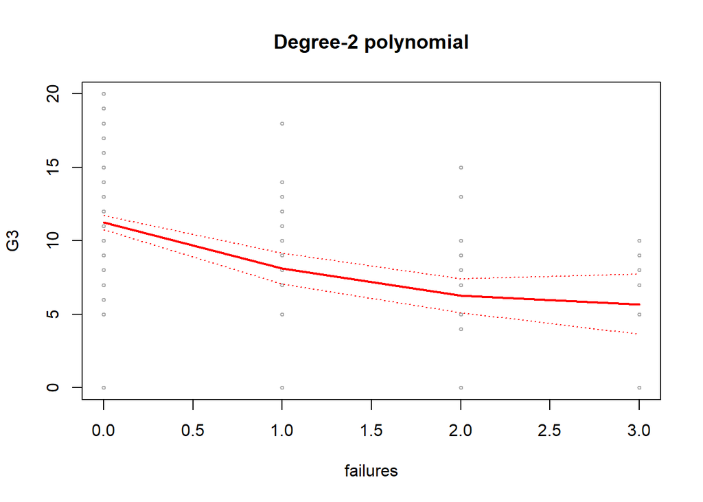

```r
faillims<-range(failures)
fail.grid<-seq(from=faillims[1],to=faillims[2])
pred<-predict(reg_plo,newdata=list(failures=fail.grid),se=TRUE)
se.band<-cbind(pred$fit-2*pred$se.fit,pred$fit+2*pred$se.fit)
plot(failures,G3,cex=.5,xlim=faillims,col="darkgrey",main = "Degree-2 polynomial")
lines(fail.grid,pred$fit,lwd=2,col="red")
matlines(fail.grid,se.band,lwd=1,col="red",lty = 3)
```

## (3) Piecewise Constant Regression

In this part, I considered the relationship between *age* and *G3*.

```r
reg_cut<-lm(G3~0+cut(age,3),data=grade3)
coeftest(reg_cut)
```

```
##
## t test of coefficients:
##
##                        Estimate Std. Error t value  Pr(>|t|)
## cut(age, 3)(15,17.3]   10.83451    0.26924 40.2414 < 2.2e-16 ***
## cut(age, 3)(17.3,19.7]  9.24528    0.44070 20.9787 < 2.2e-16 ***
## cut(age, 3)(19.7,22]   11.40000    2.02913  5.6182 3.665e-08 ***
## ---
## Signif. codes:  0 '***' 0.001 '**' 0.01 '*' 0.05 '.' 0.1 ' ' 1
```

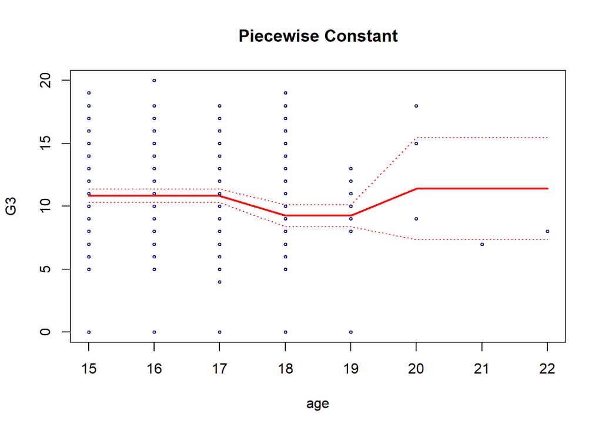

```r
agelims<-range(age)
age.grid<-seq(agelims[1],agelims[2])
pred2<-predict(reg_cut,newdata = list(age=age.grid),se=TRUE)
se.band2<-cbind(pred2$fit-2*pred2$se.fit,pred2$fit+2*pred2$se.fit)
plot(age,G3,cex=.5,xlim=agelims,col="darkblue",main="Piecewise Constant")
lines(age.grid,pred2$fit,col="red",lwd=2)
matlines(age.grid,se.band2,col="red",lwd=1,lty=3)
```

## (4) Cross Section

The variable *romantic*,represents whether has a romantic relationship. I guess that maybe boys and girls might have different action within a romantic relationship. So I consider the cross section between *sex* and *romantic*.However the regression coefficient is not significant.

```r
reg_cs<-lm(G3~sex*romantic+studytime+age+schoolsup+famsup+failures+goout+absences,data = grade3)
coeftest(reg_cs)
```

```
##
## t test of coefficients:
##
##                   Estimate Std. Error t value  Pr(>|t|)
## (Intercept)      17.777942   3.127796  5.6839 2.609e-08 ***
## sexM              0.825999   0.549020  1.5045   0.13328
## romanticyes      -1.390837   0.609277 -2.2828   0.02299 *
## studytime         0.533280   0.269782  1.9767   0.04879 *
## age              -0.386567   0.182246 -2.1211   0.03455 *
## schoolsupyes     -1.472443   0.660148 -2.2305   0.02629 *
## famsupyes        -0.587785   0.444647 -1.3219   0.18698
## failures         -1.916501   0.298320 -6.4243 3.924e-10 ***
## goout            -0.393804   0.192011 -2.0509   0.04095 *
## absences          0.064076   0.027096  2.3648   0.01854 *
## sexM:romanticyes  0.960509   0.909656  1.0559   0.29168
## ---
## Signif. codes:  0 '***' 0.001 '**' 0.01 '*' 0.05 '.' 0.1 ' ' 1
```

```r
detach(grade)
```

## Reference

P. Cortez and A. Silva. Using Data Mining to Predict Secondary School Student Performance. In A. Brito and J. Teixeira Eds., Proceedings of 5th FUture BUsiness TEChnology Conference (FUBUTEC 2008) pp. 5-12, Porto, Portugal, April, 2008, EUROSIS, ISBN 978-9077381-39-7.[Link](http://www3.dsi.uminho.pt/pcortez/student.pdf)